# Cyanobacteria in Lakes, Ponds, and Reservoirs

## Overview of US EPA, Atlantic Ecology Division Research Activities

Jeff Hollister (with Kristen Hychka, Darryl Keith, Betty Kreakie, and Bryan Milstead)

Presented at Boston Museum of Science

10/24/2013

### Disclaimer

The views expressed in this presentation are those of the author[s] and do not necessarily reflect the views or policies of the U.S. Environmental Protection Agency. It has not been subjected to peer and administrative review and does not constitute U.S.Environmental Protection Agency policy. It has not been formally disseminated by EPA. It does not represent and should not be construed to represent any Agency determination or policy. Mention of trade names or commercial products does not constitute endorsement or recommendation for use.

### Cyanobacteria Research at AED

- Background
- Research Areas
  - Ecology
  - Toxicology
  - Epidemiology
  - Remote Sensing
  - Informatics

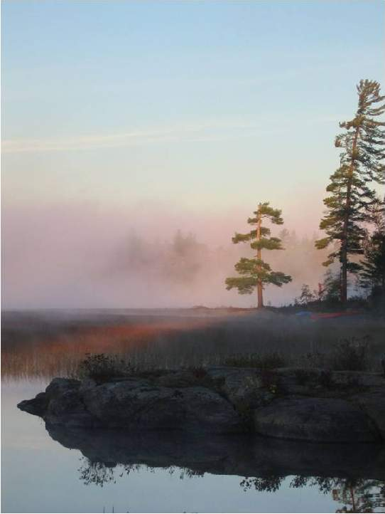

### Cyanobacteria Research at AED:

## Toxicology

- Mamalian toxicity
- Hair as biomarkers
- Research Triangle Park: Neil Chernoff

[figure not shown]

### Cyanobacteria Research at AED:

[figure not shown]

## Epidemiology

- Cyanotoxin occurence
- Exposure scenarios to assess risk to human health
- Research Triangle Park: Betsy Hilborn

### Cyanobacteria Research at AED:

## Ecology

- Modelling
  - Long-term trends in Midwest
  - National Modelling
  - Rhode Island
  - Lake Morphometry
  - Improving predictions

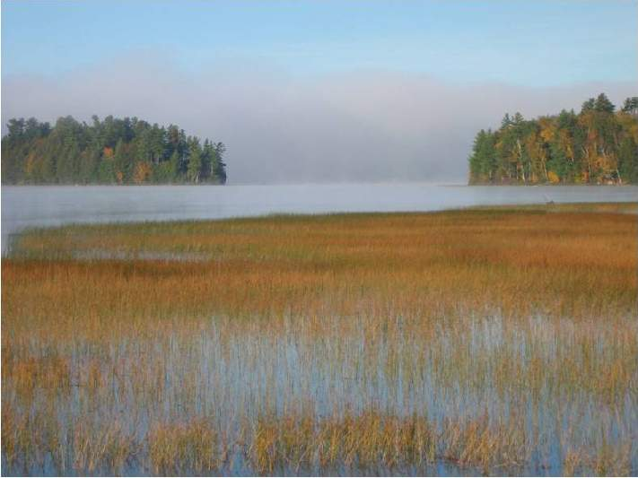

### Lake Morphometry

- Volume (2010)
- Depth (2011)

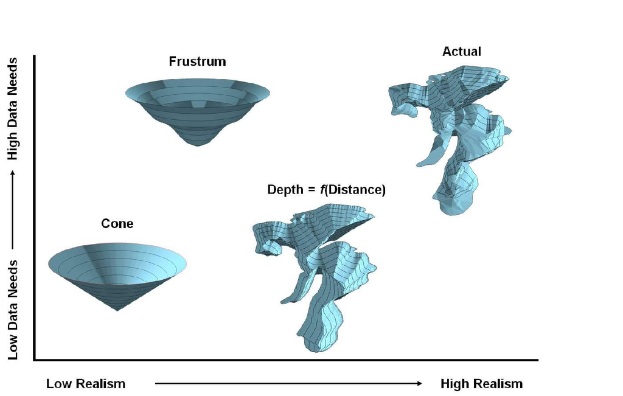

### Lake Morphometry

- Volume (2010)
- Depth (2011)

[figure not shown]

### National Lake Morphometry (2013)

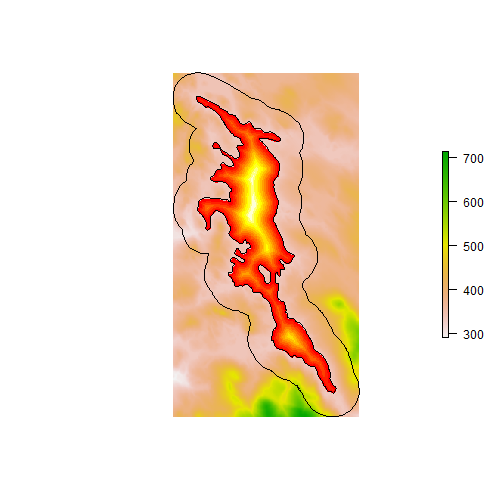

### Improving Predictions

- Nutrients
- Chlorophyl *a*

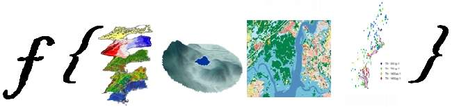

### Cyanobacteria Research at AED:

## Remote Sensing

- Satellite multispectral
- Airborne hypersepctral

[figure not shown]

### Satellite Multi- and Hyperspectral

[figure not shown]

### Airborne Hyperspectral

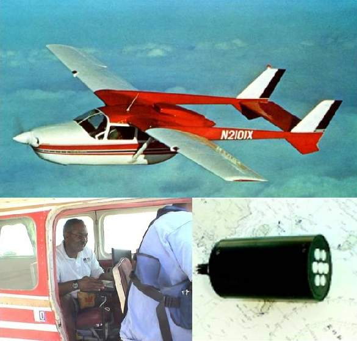

### Unmanned???

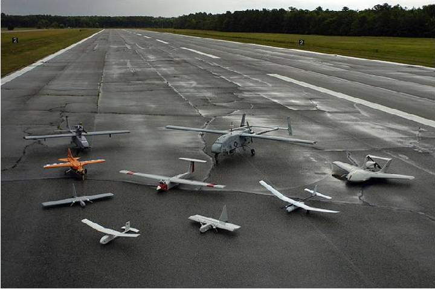

Disclaimer: EPA does NOT have, nor do we operate drones!!!

### Map

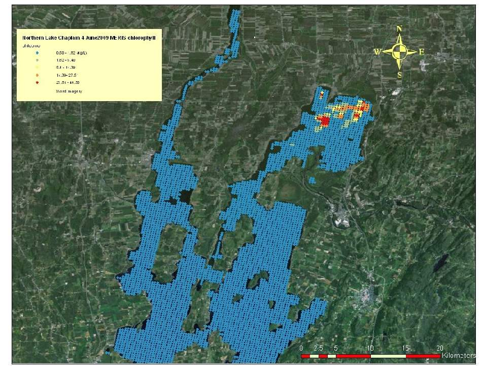

### Cyanobacteria Research at AED:

## Informatics

- Open Science
  - Access
  - Source
  - Data
- Twitter
- R Package Development
- Mobile Apps
  - Lake Chlorphyll

[figure not shown]

### Extra Slides

### National Lake Morphometry (2013)

```r
#Function to calculate shoreline development
#TO DO:
#  check for null lake
lakeShorelineDevelopment<-function(inLakeMorpho)
{
  return((gLength(inLakeMorpho$lake))/
                    (2*sqrt(pi*gArea(inLakeMorpho$lake))))
}
```